# Final Project Final

Author

Logan Agin

# Likes and Dislikes effecting Views in YouTube videos?

Logan Agin

```
here() starts at C:/Users/aginl/OneDrive/Desktop/Sociol-223-Data-Science
```

## Introduction

YouTube is a massive website where people can upload videos for others to watch. The YouTube algorithm takes multiple variables into deciding what YouTube video trends. If a video trends then the more views the video gets. I want to focus on likes and dislikes to see its relationships with views. I looked either likes or dislikes effects total views more. For this study, I looked at multiple videos posted between 2017 and 2018 that trended.

YouTube channels make money off of their videos. AD revenue, length of video and total views all effect the income of the channel’s video. This inspires creators to make videos will get them the most amount of views. Many different types of creators have made different types of videos to get the highest amount of views as possible. I want to see if the YouTube algorithm is effected more if people either like or dislikes the video. In other words, does likes or dislikes create more views.

Unfortunately, this data set does not have videos after the year 2018. YouTube has since revamped their brand and advocated for more family friendlya content. Some of the videos have either been demonetized or banned since the data was created. The dislikes button is no longer on the site as well. So for current videos this study might be outdated.

Following is a 10 random samples from our data set.

```
# A tibble: 10 × 5
   trending_date channel_title                          views likes dislikes
   <chr>         <chr>                                  <dbl> <dbl>    <dbl>
 1 17.15.12      Capital FM                           1292990 40523     3830
 2 18.24.02      The Late Show with Stephen Colbert    139909  1106      116
 3 18.19.03      Roxette Arisa                         617734 22420      487
 4 18.02.02      The Official Pokémon YouTube Channel  710551 26566     1575
 5 17.27.11      NickJonasVEVO                         212237  9987      132
 6 18.22.04      The Verge                             314539 13153      892
 7 18.18.01      20th Century Fox                     3448296 27363     2624
 8 18.05.01      Sam Sheffer                            47385  2789      245
 9 18.17.04      Anna Akana                            603548 61576     1237
10 18.20.02      Genius                                162087  7293       92
```

## Exploratory data analysis

In the data we had 50000 samples with 19 variables. The variables I will focus on is views, likes and dislikes. Many of the videos had zero likes or zero dislikes. Zero videos had zero views. The data is very skewed. Many videos outperformed others drastically. For example there are trending videos with 549 views, 9 likes and 1 dislike compared to a video with 22,521,923 views, 5,023,450 likes and 343,541 dislikes. So to combat this I logged all three variables I tested. For the videos that have zero likes or dislikes I added 1 to prevent negative infinities.

```
# A tibble: 10 × 7
   video_id       views  likes dislikes log_views log_likes log_dislikes
   <chr>          <dbl>  <dbl>    <dbl>     <dbl>     <dbl>        <dbl>
 1 TudhYwBrgYg  3693414  89889     2182     15.1      11.4          7.69
 2 lCuewNV_KyQ   236283  10765      126     12.4       9.28         4.84
 3 CX11yw6YL1w 10079114 264867     7133     16.1      12.5          8.87
 4 VYmfEx3taAM  1140097  20435      552     13.9       9.93         6.31
 5 ZJDMWVZta3M  4707527 157931     2072     15.4      12.0          7.64
 6 OVnxBcS5qWo   419536  14453      406     12.9       9.58         6.01
 7 k5wc9V7ggVg   592097   9899     2316     13.3       9.20         7.75
 8 HnnRyhuX_jM  1687203  25912     1461     14.3      10.2          7.29
 9 rQ7yPtJ5Y7I    12106     66       23      9.40      4.19         3.14
10 JVHFMBfG-cM    36934   1586      136     10.5       7.37         4.91
```

I then looked at the distribution of my log views, log likes and log dislikes.

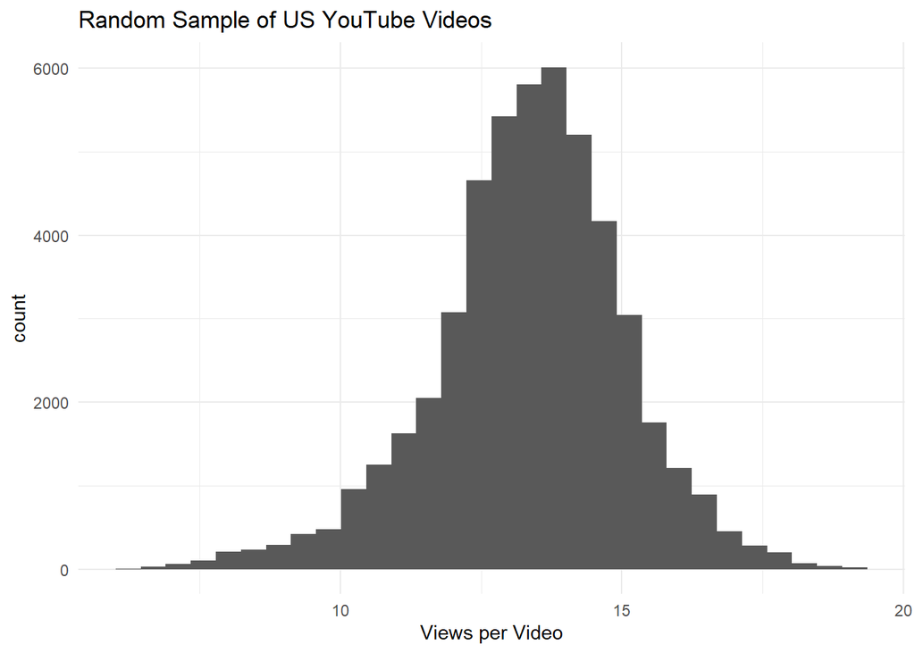

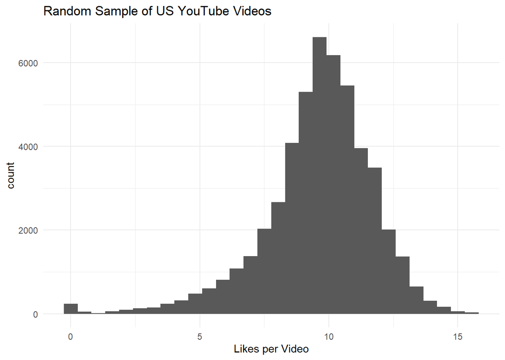

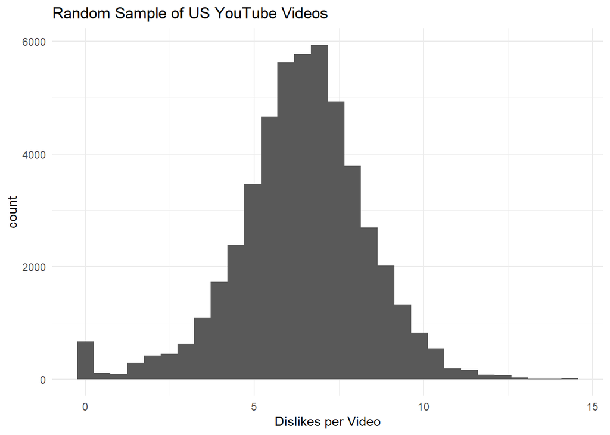

All three distributions look normal. Likes and dislikes did have a little skew to the left due to the amount of videos with low likes and dislikes.

I then created scatter plots to look at the relationships between our numerical variables, likes and dislikes, and our outcome variable, views. This is to see the overall relationship between likes and views, and dislikes and views. In both figures, as our outcome variable, views, increase our numerical variable has a positive correlation.

[figure not shown]

[figure not shown]

I then wanted to make correlation easy to read so I visualized the correlation of all variables. I want to focus on the correlation of views to likes and views to dislikes. For views to likes we see a .85 positive correlation. For views to dislikes we see a .47 positive correlation.

```
             views     likes  dislikes
views    1.0000000 0.8491765 0.4722132
likes    0.8491765 1.0000000 0.4471864
dislikes 0.4722132 0.4471864 1.0000000
```

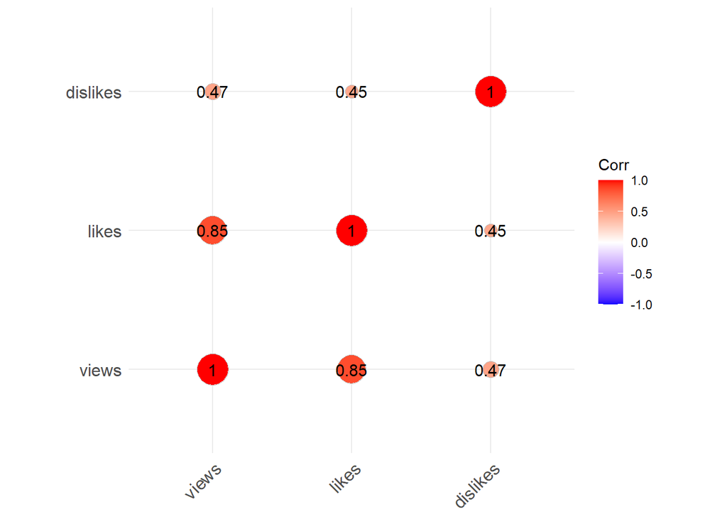

## Linear Regression

### Methods

I created two separate linear regression models using our outcome variable and two separate numerical variables.

Outcome variable y = Logged Views

Numerical variables x = Likes or Dislikes

### Model Results

The table that follows shows us the regression table of views to likes and views to dislikes.

```
# A tibble: 2 × 7
  term      estimate std_error statistic p_value lower_ci upper_ci
  <chr>        <dbl>     <dbl>     <dbl>   <dbl>    <dbl>    <dbl>
1 intercept    6.73      0.02       331.       0    6.69     6.77
2 log_likes    0.688     0.002      332.       0    0.684    0.692
```

```
# A tibble: 2 × 7
  term         estimate std_error statistic p_value lower_ci upper_ci
  <chr>           <dbl>     <dbl>     <dbl>   <dbl>    <dbl>    <dbl>
1 intercept       8.51      0.015      572.       0    8.48     8.54
2 log_dislikes    0.757     0.002      339.       0    0.753    0.762
```

### Interpreting the regression table

The regression equations for views is as follows:

Views = 6.73 + .69(likes)

Views = 8.51 + .76(dislikes)

The intercept, views, represents the views when there are zero likes and dislikes.

The estimated slope for likes (.69) is the associated change in views depending on the likes. For every 1% increase in likes then there will be an increase of .69% in views.

The estimated slope for dislikes(.76) is the associated change in views depending on dislikes. For every 1% increase in dislikes there will be a .76% increase in views.

### Inference for Regression

Using the output of the regression tables I want to perform two different null hypothesis. One for each regression analysis. The first null hypothesis being there is no relationship between likes and views on a video.

H0: likes = 0

Ha: likes != 0

There appears to be a positive relationship between likes and views. I believe between .684 or 68.4% and .692 or 69.2% of likes add a view to the video.

- the 95% confidence interval for the slope is (.684 and .692) a positive relationship
- the p-value (shown in the table as 0) is very small. Thus, we reject the null favoring that likes do effect views in a YouTube video.

The second null hypothesis is there is no relationship between dislikes and views.

H0: dislikes = 0

Ha: dislikes != 0

There appears to be a positive relationship between dislikes and views. I believe between .753 or .753% and .762 or .762% of dislikes add a view to the video.

- the 95% confidence interval for the slope is (.753 and .762) a positive relationship
- the p-value (shown in the table as 0) is very small. Again, we reject the null favoring the alternative, that dislikes do effect the views to the video.

There seems to be more of an impact with dislikes to views than likes to views. With a confidence interval of .753 and .762 compared to .684 and .692 of likes to views. We can conclude that dislikes effect views more than likes.

## Residual Analysis

I ran a residual analysis to see if there was any systematic pattern of residuals for the models I ran. If there are any patterns, we cannot fully trust our p-value and confidence intervals.

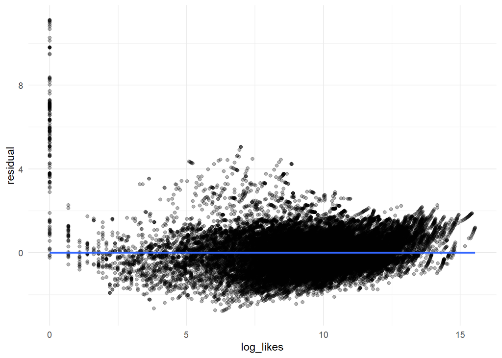

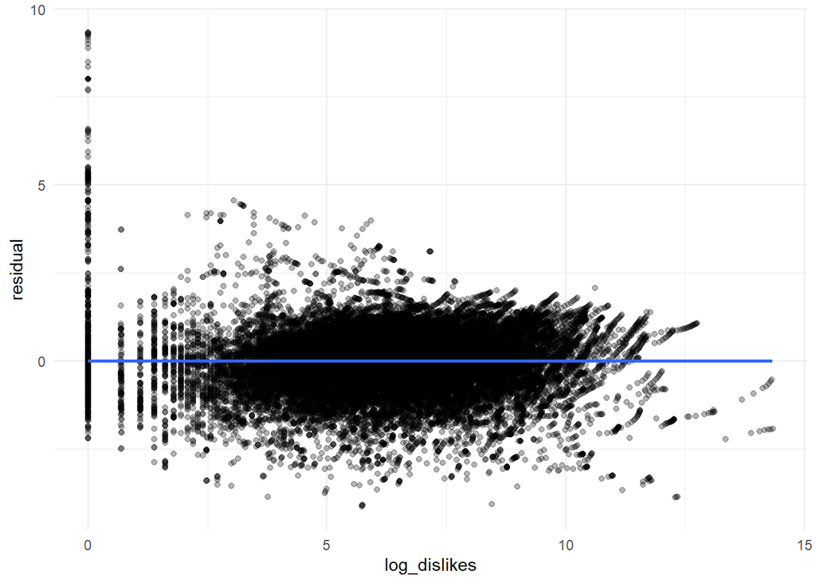

The residual plots look normally distributed, expect for at the point zero. The model suggests under predicting when log_likes = 0 and log_dislikes = 0. It would be worthwhile to look into the reasons behind this.

## Discussion

### Conclusion

In this project I aimed to understand two factors influencing the views of a YouTube video. I picked two numerical variables, likes and dislikes. Finding too much varaince between the minimun and maximum in the variables I then logged all variables to reduce it.

Both numerical variables had a positive correlation when being compared to views. This suggest that both likes and dislikes have a positive relationship to views. In simple terms, Both likes and dislikes increase when views increase and vice versa. Dislikes to views had a smaller correlation than likes to views indicating that dislikes may not have as strong of an impact on a videos popularity as likes do.

In my regression analysis, I observed that dislikes had a buigger impact on views compared to likes. The coefficients from the model suggest that, on average, a dislike has a .76% chance to increase views compared to .69% for likes. This indicates a potentially stronger influence than the impact of likes on views. This insight underscores the significance of dislikes as a factor influencing the viewership of YouTube videos.

### Limitations

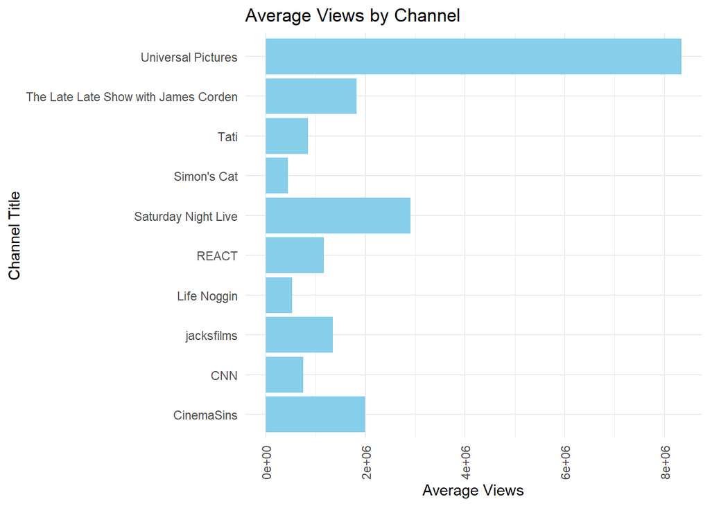

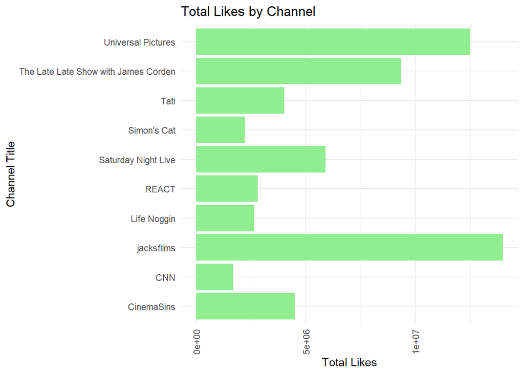

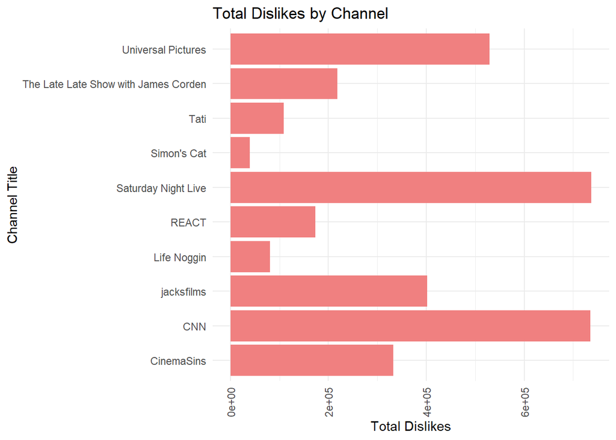

### Further Questions

There are more avenues for the project to go as well. How frequently the channel posts? Does the specific tags associated with each video effect offer more insights to the views, likes and dislikes relationship. Incorporating data over a bigger time period would also help the data.

It would also be interesting to seem how algorithms changes on YouTube over this time period effected our data, if any, YouTube constantly changes their algorithm giving channels difficulty taking this data in. Understanding how external algorithms effect the overall algorithm would also be another avenue to venture.

My current study lays the groundwork for future inquiries between content creators, viewer engagement, and the YouTube algorithm. By addressing these limitations and posing new questions, we can refine our understanding of the complex ecosystem that shapes video popularity on YouTube.